# Question

A transformed square-root function was constructed by randomly choosing integers for the values of $m$, $p$, $h$, and $k$ in the equation below.

$$y~=~m\sqrt{\frac{1}{p}(x-h)}+k$$

The equation’s curve is plotted below:

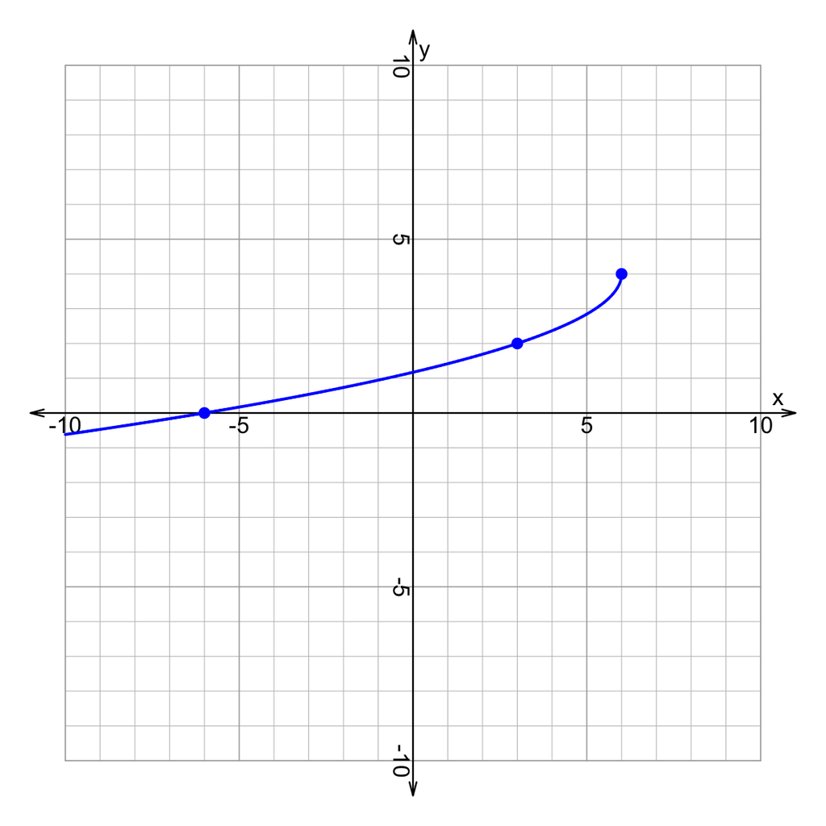

Notice, I’ve marked where the curve intersects the lattice points exactly. These points are where $x$ and $y$ are both integers. (*On the midterm, these points might not be marked.*)

Find the values of the parameters:

- $m=$ ##ANSWER1##
- $p=$ ##ANSWER2##
- $h=$ ##ANSWER3##
- $k=$ ##ANSWER4##

## Answerlist

- -7
- -6
- -5
- -4
- -3
- -2
- -1
- 0
- 1
- 2
- 3
- 4
- 5
- 6
- 7
- -7
- -6
- -5
- -4
- -3
- -2
- -1
- 0
- 1
- 2
- 3
- 4
- 5
- 6
- 7
- -7
- -6
- -5
- -4
- -3
- -2
- -1
- 0
- 1
- 2
- 3
- 4
- 5
- 6
- 7
- -7
- -6
- -5
- -4
- -3
- -2
- -1
- 0
- 1
- 2
- 3
- 4
- 5
- 6
- 7

# Solution

I recommend opening up [Desmos](https://www.desmos.com/calculator) and typing in $y~=~m\sqrt{\frac{1}{p}(x-h)}+k$, using sliders for $m$, $p$, $h$, and $k$. Then see what happens as you adjust each slider. You might also add points $(h,k)$ and $(h+p,k+m)$ to see where those move.

The given equation represents a transformation that is best thought of as stretches and then shifts. Imagine the parent function stretched vertically by factor $m$ and horizontally by factor $p$. Then, the parent function is shifted horizontally by distance $h$ and vertically by distance $k$.

The parent function, $y=\sqrt{x}$, has its endpoint at the origin. This point on the curve is unaffected by the stretches, so its corresponding point at $(6,4)$ represents the shifts only.

$$h=6$$
$$k=4$$

The parent function also goes through $(1,1)$. Because both stretches are integer multipliers, we know the corresponding point will be a lattice point on the curve. This key lattice point on the curve is at $(3,2)$. We can find $m$ and $p$ by comparing this point to the endpoint.

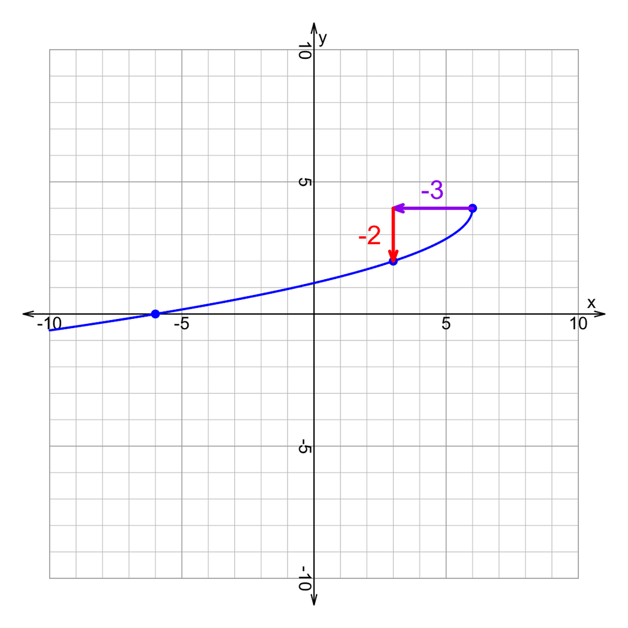

- $m=-2$
- $p=-3$
- $h=6$
- $k=4$

Thus, the equation of the curve is
$$y=-2\sqrt{\frac{1}{-3}(x-6)}+4$$

# Meta-information

extype: cloze exclozetype: schoice|schoice|schoice|schoice exsolution: 000001000000000|000010000000000|000000000000010|000000000001000 exname: trans_sqrt_params